Table of Contents

```python
%%javascript
$.getScript('https://kmahelona.github.io/ipython_notebook_goodies/ipython_notebook_toc.js')
```

# Analysis

## Data Exploration

```python
# Math stuff
import numpy as np
# For handling dataset
import pandas as pd
# For plotting
import matplotlib.pyplot as plt
# For plotting
import seaborn as sns
sns.set_style("white")
# For plotting
import plotly.plotly as py
import plotly.graph_objs as go
# For list the feature importance
from sklearn.ensemble import RandomForestClassifier
# For feature transformation
from sklearn.preprocessing import FunctionTransformer
# helping to remove outliers
from scipy.stats import iqr
# For undersampling
from imblearn.under_sampling import RandomUnderSampler
# metrics
from sklearn.metrics import precision_recall_curve
from sklearn.metrics import average_precision_score
```

Let's load the data in order to do some analysis

```python
df = pd.read_csv('creditcard.csv')
```

```python
df.head()
```

|  | Time | V1 | V2 | V3 | V4 | V5 | V6 | V7 | V8 | V9 | ... | V21 | V22 | V23 | V24 | V25 | V26 | V27 | V28 | Amount | Class |
| --- | --- | --- | --- | --- | --- | --- | --- | --- | --- | --- | --- | --- | --- | --- | --- | --- | --- | --- | --- | --- | --- |
| 0 | 0.0 | -1.359807 | -0.072781 | 2.536347 | 1.378155 | -0.338321 | 0.462388 | 0.239599 | 0.098698 | 0.363787 | ... | -0.018307 | 0.277838 | -0.110474 | 0.066928 | 0.128539 | -0.189115 | 0.133558 | -0.021053 | 149.62 | 0 |
| 1 | 0.0 | 1.191857 | 0.266151 | 0.166480 | 0.448154 | 0.060018 | -0.082361 | -0.078803 | 0.085102 | -0.255425 | ... | -0.225775 | -0.638672 | 0.101288 | -0.339846 | 0.167170 | 0.125895 | -0.008983 | 0.014724 | 2.69 | 0 |
| 2 | 1.0 | -1.358354 | -1.340163 | 1.773209 | 0.379780 | -0.503198 | 1.800499 | 0.791461 | 0.247676 | -1.514654 | ... | 0.247998 | 0.771679 | 0.909412 | -0.689281 | -0.327642 | -0.139097 | -0.055353 | -0.059752 | 378.66 | 0 |
| 3 | 1.0 | -0.966272 | -0.185226 | 1.792993 | -0.863291 | -0.010309 | 1.247203 | 0.237609 | 0.377436 | -1.387024 | ... | -0.108300 | 0.005274 | -0.190321 | -1.175575 | 0.647376 | -0.221929 | 0.062723 | 0.061458 | 123.50 | 0 |
| 4 | 2.0 | -1.158233 | 0.877737 | 1.548718 | 0.403034 | -0.407193 | 0.095921 | 0.592941 | -0.270533 | 0.817739 | ... | -0.009431 | 0.798278 | -0.137458 | 0.141267 | -0.206010 | 0.502292 | 0.219422 | 0.215153 | 69.99 | 0 |

5 rows × 31 columns

```python
df.dtypes
```

```
Time      float64
V1        float64
V2        float64
V3        float64
V4        float64
V5        float64
V6        float64
V7        float64
V8        float64
V9        float64
V10       float64
V11       float64
V12       float64
V13       float64
V14       float64
V15       float64
V16       float64
V17       float64
V18       float64
V19       float64
V20       float64
V21       float64
V22       float64
V23       float64
V24       float64
V25       float64
V26       float64
V27       float64
V28       float64
Amount    float64
Class       int64
dtype: object
```

As we can see, the dataset contains 31 features which each one is a numerical data.  
The feature Class is a categorical data labeling if the transaction is legit or fraud.  
One of the characteristics is the highly imbalance between legit and fraud transaction.

So, let's plot and see it.

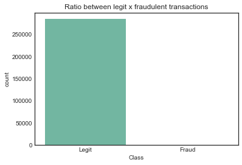

```python
fig = plt.figure()

sns.countplot(df.Class, palette="Set2")
plt.xticks([0,1], ['Legit', 'Fraud'])
plt.title('Ratio between legit x fraudulent transactions')

# fig.savefig('imgs/fig2 ratio-legitxfraud.png')

plt.show()
```

Now, let's summarize the whole data...

```python
df.describe().transpose()[::-1]
```

|  | count | mean | std | min | 25% | 50% | 75% | max |
| --- | --- | --- | --- | --- | --- | --- | --- | --- |
| Class | 284807.0 | 1.727486e-03 | 0.041527 | 0.000000 | 0.000000 | 0.000000 | 0.000000 | 1.000000 |
| Amount | 284807.0 | 8.834962e+01 | 250.120109 | 0.000000 | 5.600000 | 22.000000 | 77.165000 | 25691.160000 |
| V28 | 284807.0 | -1.220404e-16 | 0.330083 | -15.430084 | -0.052960 | 0.011244 | 0.078280 | 33.847808 |
| V27 | 284807.0 | -3.666453e-16 | 0.403632 | -22.565679 | -0.070840 | 0.001342 | 0.091045 | 31.612198 |
| V26 | 284807.0 | 1.687098e-15 | 0.482227 | -2.604551 | -0.326984 | -0.052139 | 0.240952 | 3.517346 |
| V25 | 284807.0 | 5.340915e-16 | 0.521278 | -10.295397 | -0.317145 | 0.016594 | 0.350716 | 7.519589 |
| V24 | 284807.0 | 4.471968e-15 | 0.605647 | -2.836627 | -0.354586 | 0.040976 | 0.439527 | 4.584549 |
| V23 | 284807.0 | 2.578648e-16 | 0.624460 | -44.807735 | -0.161846 | -0.011193 | 0.147642 | 22.528412 |
| V22 | 284807.0 | -3.444850e-16 | 0.725702 | -10.933144 | -0.542350 | 0.006782 | 0.528554 | 10.503090 |
| V21 | 284807.0 | 1.656562e-16 | 0.734524 | -34.830382 | -0.228395 | -0.029450 | 0.186377 | 27.202839 |
| V20 | 284807.0 | 6.406703e-16 | 0.770925 | -54.497720 | -0.211721 | -0.062481 | 0.133041 | 39.420904 |
| V19 | 284807.0 | 1.039817e-15 | 0.814041 | -7.213527 | -0.456299 | 0.003735 | 0.458949 | 5.591971 |
| V18 | 284807.0 | 9.572133e-16 | 0.838176 | -9.498746 | -0.498850 | -0.003636 | 0.500807 | 5.041069 |
| V17 | 284807.0 | -3.800113e-16 | 0.849337 | -25.162799 | -0.483748 | -0.065676 | 0.399675 | 9.253526 |
| V16 | 284807.0 | 1.437666e-15 | 0.876253 | -14.129855 | -0.468037 | 0.066413 | 0.523296 | 17.315112 |
| V15 | 284807.0 | 4.913003e-15 | 0.915316 | -4.498945 | -0.582884 | 0.048072 | 0.648821 | 8.877742 |
| V14 | 284807.0 | 1.206296e-15 | 0.958596 | -19.214325 | -0.425574 | 0.050601 | 0.493150 | 10.526766 |
| V13 | 284807.0 | 8.176030e-16 | 0.995274 | -5.791881 | -0.648539 | -0.013568 | 0.662505 | 7.126883 |
| V12 | 284807.0 | -1.254995e-15 | 0.999201 | -18.683715 | -0.405571 | 0.140033 | 0.618238 | 7.848392 |
| V11 | 284807.0 | 1.673327e-15 | 1.020713 | -4.797473 | -0.762494 | -0.032757 | 0.739593 | 12.018913 |
| V10 | 284807.0 | 2.239751e-15 | 1.088850 | -24.588262 | -0.535426 | -0.092917 | 0.453923 | 23.745136 |
| V9 | 284807.0 | -2.406455e-15 | 1.098632 | -13.434066 | -0.643098 | -0.051429 | 0.597139 | 15.594995 |
| V8 | 284807.0 | 1.177556e-16 | 1.194353 | -73.216718 | -0.208630 | 0.022358 | 0.327346 | 20.007208 |
| V7 | 284807.0 | -5.556467e-16 | 1.237094 | -43.557242 | -0.554076 | 0.040103 | 0.570436 | 120.589494 |
| V6 | 284807.0 | 1.490107e-15 | 1.332271 | -26.160506 | -0.768296 | -0.274187 | 0.398565 | 73.301626 |
| V5 | 284807.0 | 9.604066e-16 | 1.380247 | -113.743307 | -0.691597 | -0.054336 | 0.611926 | 34.801666 |
| V4 | 284807.0 | 2.086869e-15 | 1.415869 | -5.683171 | -0.848640 | -0.019847 | 0.743341 | 16.875344 |
| V3 | 284807.0 | -1.373150e-15 | 1.516255 | -48.325589 | -0.890365 | 0.179846 | 1.027196 | 9.382558 |
| V2 | 284807.0 | 3.416908e-16 | 1.651309 | -72.715728 | -0.598550 | 0.065486 | 0.803724 | 22.057729 |
| V1 | 284807.0 | 1.165980e-15 | 1.958696 | -56.407510 | -0.920373 | 0.018109 | 1.315642 | 2.454930 |
| Time | 284807.0 | 9.481386e+04 | 47488.145955 | 0.000000 | 54201.500000 | 84692.000000 | 139320.500000 | 172792.000000 |

This summary is hard to see something. But, here some things to notice:

- The mean of the feature V1 to V28 are next to zero.
- The difference between the max value and the 75% quantile of the feature Amount is huge.

Let's plot the distributions of the features Vs.

```python
feats = df.columns[1:-2]
print feats
```

```
Index([u'V1', u'V2', u'V3', u'V4', u'V5', u'V6', u'V7', u'V8', u'V9', u'V10',
       u'V11', u'V12', u'V13', u'V14', u'V15', u'V16', u'V17', u'V18', u'V19',
       u'V20', u'V21', u'V22', u'V23', u'V24', u'V25', u'V26', u'V27', u'V28'],
      dtype='object')
```

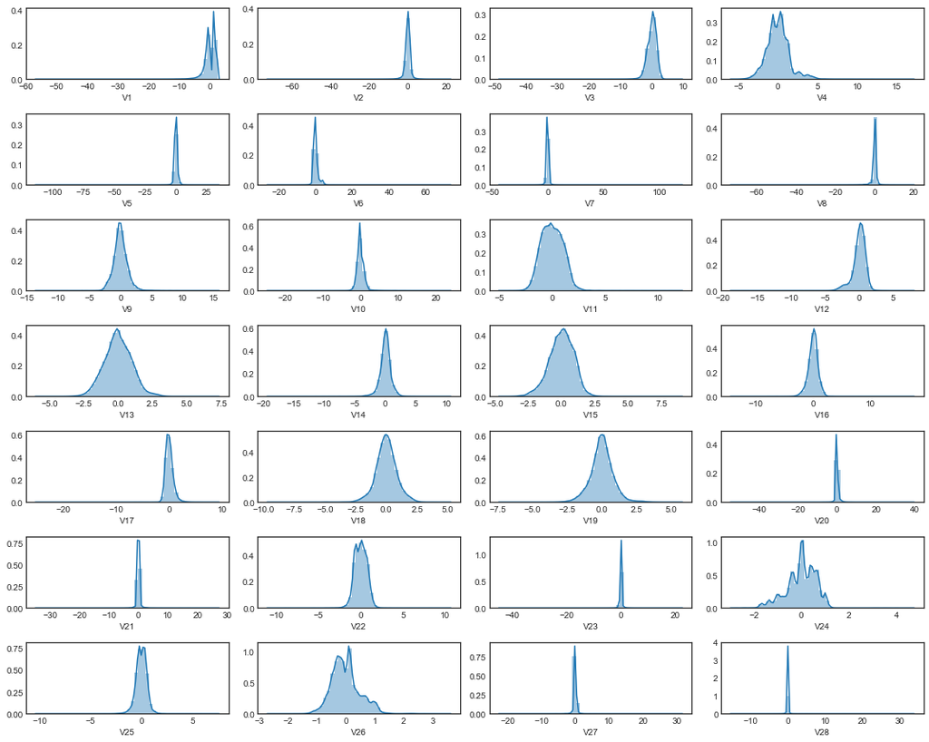

```python
fig = plt.figure(figsize=(15, 12))

for idx, feat in enumerate(feats):
    plt.subplot(7, 4, idx+1)
    sns.distplot(df[feat])

plt.tight_layout()
plt.show()

# fig.savefig('imgs/Vs distplot.png')
```

The plot above is clear to see that the mean is around zero. So, it reflects the summary.  
Another thing to notice is that by the extension of the x-axis, show us that all them have outliers.

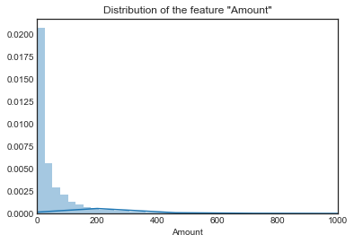

```python
fig = plt.figure()

plt.title('Distribution of the feature "Amount"')
sns.distplot(df.Amount, bins=1000)
plt.xlim(0, 1000)
plt.show()

# fig.savefig('imgs/fig3.png')
```

The feature amount is positively-skewed. So, it will need a transformation.

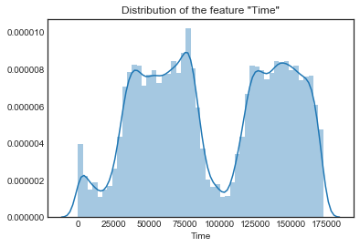

```python
fig = plt.figure()

sns.distplot(df.Time)
plt.title('Distribution of the feature "Time"')
plt.show()

# fig.savefig('imgs/fig4.png')
```

This feature presents somehow a bimodal distribution. Since, the dataset contains transactions of two days, this could be a reflection of it.

## Data Preprocessing

### Feature Selection

Now that we had an overview about the dataset, it might be a good idea to choose the features that most explain the relation between legit and fraud.

I'll be doing this through Random Forest and list the features by importance.  
Since Decision Trees aren't sensitive to outliers, it should be fine to just run it.

```python
# Since I won't be working with recurrent model, I'll be ignoring this feature
del df['Time']
```

```python
# making a copy of the data to work
X = df.iloc[:,:].copy()
```

```python
np.bincount(X.Class)
```

```
array([284315,    492], dtype=int64)
```

```python
# separating the predictors and the labels
X, y = X.iloc[:,:-1], X.iloc[:,-1]
```

```python
rus = RandomUnderSampler(ratio={0:246*20, 1:246}, random_state=0, return_indices=True)
```

```python
X_resampled, y_resampled, idx = rus.fit_sample(X, y)
```

```python
from sklearn.model_selection import GridSearchCV
```

```python
parameter_candidates = [
  {'n_estimators': [5, 10, 15, 20], 'criterion': ['gini', 'entropy'], \
   'random_state':[0], 'class_weight':['balanced', None], 'bootstrap':[True], \
   'oob_score':[True, False], 'min_samples_split':[2, 4, 6, 8], 'min_samples_leaf':[1, 2, 4, 6, 8]},

  {'n_estimators': [5, 10, 15, 20], 'criterion': ['gini', 'entropy'], \
   'random_state':[0], 'class_weight':['balanced', None], 'bootstrap':[False], \
   'min_samples_split':[2, 4, 6, 8], 'min_samples_leaf':[1, 2, 4, 6, 8]}
]
```

```python
from sklearn.metrics import make_scorer
```

```python
scoring = {'AUC':make_scorer(average_precision_score)}
```

```python
# Create a classifier object with the classifier and parameter candidates
clf = GridSearchCV(estimator=RandomForestClassifier(), param_grid=parameter_candidates, n_jobs=-1, scoring=make_scorer(average_precision_score))
```

```python
clf.fit(X_resampled, y_resampled)
```

```
GridSearchCV(cv=None, error_score='raise',
       estimator=RandomForestClassifier(bootstrap=True, class_weight=None, criterion='gini',
            max_depth=None, max_features='auto', max_leaf_nodes=None,
            min_impurity_decrease=0.0, min_impurity_split=None,
            min_samples_leaf=1, min_samples_split=2,
            min_weight_fraction_leaf=0.0, n_estimators=10, n_jobs=1,
            oob_score=False, random_state=None, verbose=0,
            warm_start=False),
       fit_params=None, iid=True, n_jobs=-1,
       param_grid=[{'n_estimators': [5, 10, 15, 20], 'oob_score': [True, False], 'random_state': [0], 'criterion': ['gini', 'entropy'], 'min_samples_split': [2, 4, 6, 8], 'bootstrap': [True], 'min_samples_leaf': [1, 2, 4, 6, 8], 'class_weight': ['balanced', None]}, {'bootstrap': [False], 'min_sample…
       pre_dispatch='2*n_jobs', refit=True, return_train_score=True,
       scoring=make_scorer(average_precision_score), verbose=0)
```

```python
clf.best_estimator_
```

```
RandomForestClassifier(bootstrap=True, class_weight=None, criterion='entropy',
            max_depth=None, max_features='auto', max_leaf_nodes=None,
            min_impurity_decrease=0.0, min_impurity_split=None,
            min_samples_leaf=1, min_samples_split=8,
            min_weight_fraction_leaf=0.0, n_estimators=20, n_jobs=1,
            oob_score=True, random_state=0, verbose=0, warm_start=False)
```

```python
importance = {item[0]:float(item[1]) for item in zip(df.columns[1:-1], clf.best_estimator_.feature_importances_)}
feat_imp = []
for w in sorted(importance.iteritems(), key=lambda (k,v):(v,k), reverse=True):
    feat_imp.append(np.array(w))
feat_imp = np.array(feat_imp)
print feat_imp[:5]

sum([ float(feat[1]) for feat in feat_imp[:3]])
```

```
[['V15' '0.333545419615']
 ['V18' '0.135330758677']
 ['V11' '0.131245952475']
 ['V13' '0.0895804541454']
 ['V8' '0.0612014911441']]
```

```
0.600122130767
```

```python
# making prediction
y_pred = clf.predict(X.iloc[~idx])

precision, recall, _ = precision_recall_curve(y_pred, y.iloc[~idx])
auc = average_precision_score(y_true=y.iloc[~idx], y_score=y_pred)
print 'precision %.2f' % precision[1]
print 'recall %.2f' % recall[1]
print 'auc %.2f' % auc
```

```
precision 0.90
recall 0.90
auc 0.81
```

The classifier performed very well.  
The five features that we will be using is V15, V11, V18, V13 and V8. <br/ >

Let's take a closer look at the three most relevants...

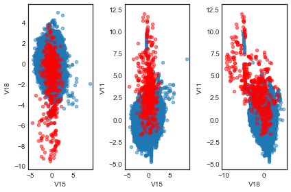

```python
xfeat, yfeat, zfeat = feat_imp[0][0], feat_imp[1][0], feat_imp[2][0]

ax = plt.subplot(131)
X[y==0].plot.scatter(x=xfeat, y=yfeat, ax=ax, alpha=.5)
X[y==1].plot.scatter(x=xfeat, y=yfeat, ax=ax, alpha=.5, c='r')

ax = plt.subplot(132)
X[y==0].plot.scatter(x=xfeat, y=zfeat, ax=ax, alpha=.5)
X[y==1].plot.scatter(x=xfeat, y=zfeat, ax=ax, alpha=.5, c='r')

ax = plt.subplot(133)
X[y==0].plot.scatter(x=yfeat, y=zfeat, ax=ax, alpha=.5)
X[y==1].plot.scatter(x=yfeat, y=zfeat, ax=ax, alpha=.5, c='r')

plt.tight_layout()
plt.show()
```

plotting in 3D...

```python
legit, fraud = df[df.Class==0].copy(), df[df.Class==1].copy()
```

```python
idx = np.random.choice(range(len(legit)), 1000)
```

```python
legit_sample = legit.loc[idx]
```

```python
trace1 = go.Scatter3d(
    x=legit_sample.V11,
    y=legit_sample.V15,
    z=legit_sample.V18,
    mode='markers',
    name='legit',
    marker=dict(
        size=2,
        line=dict(
            color='rgba(0, 0, 217, 0.14)',
            width=0.1
        ),
        opacity=0.2
    )
)

trace2 = go.Scatter3d(
    x=fraud.V11,
    y=fraud.V15,
    z=fraud.V18,
    mode='markers',
    name='fraud',
    marker=dict(
        size=2,
        color='rgb(255, 127, 127)',
        symbol='circle',
        line=dict(
            color='rgb(204, 204, 204)',
            width=.1
        ),
        opacity=1.
    )
)
data = [trace1, trace2]

layout = go.Layout(
    title='Scatterplot between %s x %s x %s'%(xfeat, yfeat, zfeat),
    scene=dict(
        xaxis=dict(title='V11'),
        yaxis=dict(title='V15'),
        zaxis=dict(title='V18')
    ),
    margin=dict(
        l=0,
        r=0,
        b=0,
        t=27
    )
)

fig = go.Figure(data=data, layout=layout)
py.iplot(fig, filename='simple-3d-scatter')
# the interactive plot works better on the firefox
```

[interactive chart not shown]

It's clear to see in the 3D plot the relation between fraud and legit.  
It seems that there is two cluster of legit transactions and the fraud transactions are spread away of them.

### Outlier removal

by looking at the following boxplot, we can see that there are a lot of outliers. this might be bias the model since the outliers might influence on the mean of the data, and the classifier might not perform very well.

```python
feats = [feat[0] for feat in feat_imp[:5]]
```

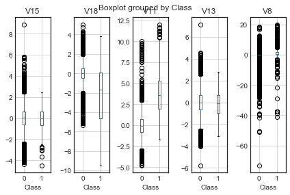

```python
fig, axis = plt.subplots(1, 5)

for feat, ax in zip(feats, axis):
    df.boxplot(feat, 'Class', ax=ax)

plt.tight_layout()
plt.show()
```

```python
legit = legit[feats]
fraud = fraud[feats]
# now i'll be removing the outliers
# since the fraudulent ones are scarce, I'll keep them
# removing outliers from legit sample
for idx, feat in enumerate(legit.columns):
    q75, q25 = np.percentile(legit[feat], [75 ,25])
    iqr_ = iqr(legit[feat])*1.5

    greater = np.array(legit[feat] <= q25 - iqr_, dtype=bool)
    legit.loc[greater, feat] = np.nan

    lower   = np.array(legit[feat] >= q75 + iqr_, dtype=bool)
    legit.loc[lower, feat] = np.nan
legit = pd.concat([legit, fraud], axis=0)
legit = pd.concat([legit, y], axis=1)
legit = legit.dropna()
# checking if there is a missing value
legit.isnull().sum()
```

```
V15      0
V18      0
V11      0
V13      0
V8       0
Class    0
dtype: int64
```

```python
len(df) - len(legit)
```

```
36023
```

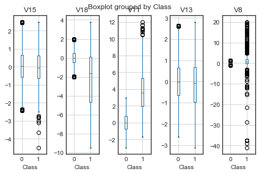

```python
fig, axis = plt.subplots(1, 5)

for feat, ax in zip(feats, axis):
    legit.boxplot(feat, 'Class', ax=ax)

plt.tight_layout()
plt.show()
```

```python
# separating the predictors and the labels
X, y = legit.iloc[:,:-1], legit.iloc[:,-1]
```

## Benchmark

### One-class SVM

The main idea of the model is to classify one class.  
So, we'll undersampling with zero fraud transactions in order to train the classifier.

```python
# Model used as a benchmark
from sklearn.svm import OneClassSVM
from sklearn.naive_bayes import GaussianNB
```

```python
rus = RandomUnderSampler(random_state=0, ratio={0:246*61, 1:0}, return_indices=True)
X_resampled, y_resampled, idxs = rus.fit_sample(X, y)
```

Here I tried some inputs nu and gamma.  
The following one was the highest auc that I achieved

```python
one_class_clf = OneClassSVM(nu=.00101001, gamma=0.000010, kernel='rbf')
one_class_clf.fit(X_resampled)
```

```
OneClassSVM(cache_size=200, coef0=0.0, degree=3, gamma=1e-05, kernel='rbf',
      max_iter=-1, nu=0.00101001, random_state=None, shrinking=True,
      tol=0.001, verbose=False)
```

Since the *RandomUnderSampler* returns the indexes, we can use them to get the rest of the samples in order to validate the classifier.

```python
y_pred = one_class_clf.predict(X[~y.index.isin(idxs)])
```

The classifier just classifies if a transaction is legit or not.  
The classifier returns 1 or -1. So, we should set up the predictions before submitting them on the metrics procedure.

```python
y_pred[y_pred==1] = 0
y_pred[y_pred==-1] = 1
```

```python
y_true = y[~y.index.isin(idxs)]
```

```python
precision, recall, _ = precision_recall_curve(y_pred, y_true)
auc = average_precision_score(y_true=y_true, y_score=y_pred)

print 'precision %s' % precision
print 'recall    %s' % recall
print 'auc %s' % auc
```

```
precision [ 0.00182849  0.65605096  1.        ]
recall    [ 1.          0.71693735  0.        ]
auc 0.471034710272
```

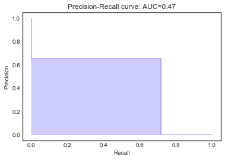

```python
# code from scikit-learn
# ref: http://scikit-learn.org/stable/auto_examples/model_selection/plot_precision_recall.html#plot-the-precision-recall-curve
plt.step(recall, precision, color='b', alpha=0.2, where='post')
plt.fill_between(recall, precision, step='post', alpha=0.2, color='b')

plt.xlabel('Recall')
plt.ylabel('Precision')
plt.title('Precision-Recall curve: AUC={0:0.2f}'.format(auc))
plt.show()
```

### GaussianNB

I'll be using the same approach to train the GaussianNB.  
However, I'll be including fraud samples since this isn't a one-class classifier.

```python
rus = RandomUnderSampler(ratio={0:246*60, 1:246}, random_state=0, return_indices=True)
X_resampled, y_resampled, idxes = rus.fit_sample(X, y)
```

```python
nb_clf = GaussianNB()
nb_clf.fit(X_resampled, y_resampled)
```

```
GaussianNB(priors=None)
```

Using the same approach, I'll validate it with the rest of the samples

```python
y_pred = nb_clf.predict(X[~y.index.isin(idxs)])
y_true = y[~y.index.isin(idxs)]
```

```python
precision, recall, _ = precision_recall_curve(y_pred, y_true)
auc = average_precision_score(y_true=y_true, y_score=y_pred)

print 'precision %s' % precision
print 'recall    %s' % recall
print 'auc %s' % auc
```

```
precision [ 0.00136606  0.68152866  1.        ]
recall    [ 1.          0.99689441  0.        ]
auc 0.680048478187
```

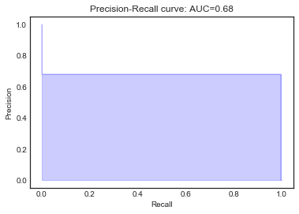

```python
plt.step(recall, precision, color='b', alpha=0.2, where='post')
plt.fill_between(recall, precision, step='post', alpha=0.2, color='b')

plt.xlabel('Recall')
plt.ylabel('Precision')
plt.title('Precision-Recall curve: AUC={0:0.2f}'.format(auc))
plt.show()
```

## Implementation

Here, I'll be running an anomaly detection approach.  
I'll be using the Gaussian Mixture Model provided by scikit-learn and the 't Mixture Model' implemented by me, but proposed by D. Peel and G. J. McLachlan (Robust Mixture modelling using the t distribution).  
**Most of the implementations were based on the scikit-learn GaussianMixture.**

```python
from numpy.linalg import inv
# models the I'll choosed to approach the problem
from sklearn.mixture import GaussianMixture
from multivariate_t_mixture import MultivariateTMixture as t_mix
# used to calc the threshold
from scipy.stats import chi2
from scipy.spatial.distance import mahalanobis
```

### Approach #01

#### Gaussian Model #01

First, I'll try to find a threshold using the same approach of the one-class SVM.  
That is, there aren't any fraud sample on the training set.

```python
rus = RandomUnderSampler(random_state=0, ratio={0:246*61, 1:0}, return_indices=True)
X_resampled, y_resampled, idxs = rus.fit_sample(X, y)
```

```python
# validation set labels
y_true = y[~y.index.isin(idxs)]
```

```python
# estimating the parameters
gauss_clf = GaussianMixture(n_components=1)
gauss_clf.fit(X_resampled)
```

```
GaussianMixture(covariance_type='full', init_params='kmeans', max_iter=100,
        means_init=None, n_components=1, n_init=1, precisions_init=None,
        random_state=None, reg_covar=1e-06, tol=0.001, verbose=0,
        verbose_interval=10, warm_start=False, weights_init=None)
```

Now, I'll calc the mahalanobis distance on the validation set

```python
mu  = gauss_clf.means_[0]
sig = inv(gauss_clf.covariances_[0])

y_score = []
for x in X[~y.index.isin(idxs)].as_matrix():
    y_score.append(mahalanobis(x, mu, sig))
```

Now, we'll use the chi-squared distribution in order to calculate our confidence interval.  
The chi2 function receive the confidence interval and the degrees of freedom.  
Since we're using five features, then the defrees of freedom is five.

The idea here is to label transactions as fraud those that are not inside the confidence interval.

```python
t = chi2.ppf(0.975, 5) ** .5

# if not inside the confidence interval, it'll be labeled as fraud (1)
y_pred = [1 if y_ > t else 0 for y_ in y_score]
auc = average_precision_score(y_true=y_true, y_score=y_pred)
print auc
```

```
0.0519383968696
```

```python
confidence_intervals = np.arange(.975, .9999, .0001)

best = (0, 0, 0, 0)
for interval in confidence_intervals:
    # set the threshold
    t = chi2.ppf(interval, 5) ** .5

    # make the predictions
    y_pred = [1 if y_ > t else 0 for y_ in y_score]
    # measure the performance
    auc = average_precision_score(y_true=y_true, y_score=y_pred)

    if auc > best[1]:
        precision, recall, _ = precision_recall_curve(y_pred, y_true)
        best = (interval, auc, precision, recall)

print best
```

```
(0.99969999999999726, 0.62132067010301451, array([ 0.00141273,  0.66242038,  1.        ]), array([ 1.        ,  0.93693694,  0.        ]))
```

Now, with a confidence interval of 99.97% we improved the AUC to .62

Now, let's try increasing the number of mixtures.  
With more than one mixture, I'll be using the log likelihood of the sample as a guide to set a threshold.

```python
mixes = np.arange(2, 7)
track = {}
for mix in mixes:
    # estimating the parameters
    gauss_clf = GaussianMixture(n_components=mix, random_state=1)
    gauss_clf.fit(X_resampled)

    # calc the scores
    y_score = gauss_clf.score_samples(X[~y.index.isin(idxs)].as_matrix())

    track[mix] = {'best':(0, 0, 0, 0)}
    rmin, rmax = -20, -10
    step = 1.

    # finding out a threshold
    for _ in range(5):
        intervals = np.arange(rmin, rmax, step)
        for interval in intervals:
            y_pred = [1 if y_ < interval else 0 for y_ in y_score]

            auc = average_precision_score(y_true=y_true, y_score=y_pred)

            if auc > track[mix]['best'][1]:
                precision, recall, _ = precision_recall_curve(y_pred, y_true)
                track[mix]['best'] = (interval, auc, precision, recall)
        # after finding out the best interval, we try to improve by updating the intervals
        step /= 10.
        rmin, rmax = track[mix]['best'][0] - step*10, track[mix]['best'][0] + step*10
```

```python
track
```

```
{2: {'best': (-17.399999999999977,
   0.66762020781302744,
   array([ 0.00139152,  0.68152866,  1.        ]),
   array([ 1.        ,  0.97865854,  0.        ]))},
 3: {'best': (-16.189999999999973,
   0.69100516498855258,
   array([ 0.00144667,  0.70700637,  1.        ]),
   array([ 1.        ,  0.97653959,  0.        ]))},
 4: {'best': (-16.059999999999967,
   0.65087413320907606,
   array([ 0.00137455,  0.66878981,  1.        ]),
   array([ 1.        ,  0.97222222,  0.        ]))},
 5: {'best': (-16.59999999999998,
   0.67133508778816919,
   array([ 0.00148909,  0.70700637,  1.        ]),
   array([ 1.        ,  0.94871795,  0.        ]))},
 6: {'best': (-17.179999999999971,
   0.63393637224908839,
   array([ 0.00134061,  0.65180467,  1.        ]),
   array([ 1.        ,  0.97151899,  0.        ]))}}
```

After some tries, I found out that with 3 mixtures the AuC got as good as the GaussianNB benchmark.

Let's see a histogram of the classifier with the best AuC score.

```python
gauss_clf = GaussianMixture(3)
gauss_clf.fit(X_resampled)
```

```
GaussianMixture(covariance_type='full', init_params='kmeans', max_iter=100,
        means_init=None, n_components=3, n_init=1, precisions_init=None,
        random_state=None, reg_covar=1e-06, tol=0.001, verbose=0,
        verbose_interval=10, warm_start=False, weights_init=None)
```

```python
scores = gauss_clf.score_samples(X[~y.index.isin(idxs)].as_matrix())
```

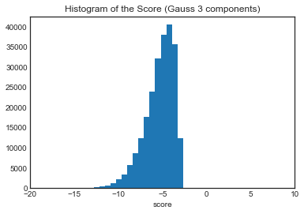

```python
plt.hist(scores, bins=10000)
plt.xlim(-20, 10)
plt.title('Histogram of the Score (Gauss 3 components)')
plt.xlabel('score')
plt.show()
```

Here we can see that most of the transactions might score next to -5 and as the scores goes $-\infty$, the probability to be a fraud increases.

#### t Model #01

Let's try with the t distribution, and compare them

```python
t_clf = t_mix(n_components=1, random_state=0)
t_clf.fit(X_resampled)
```

Using the same approach as before, we'll calculate the mahalanobis.

```python
mu  = t_clf.means[0]
sig = inv(t_clf.covariances[0])

y_score = []
for x in X[~y.index.isin(idxs)].as_matrix():
    y_score.append(mahalanobis(x, mu, sig))
```

Now, let's predict using the confidence interval

```python
t = chi2.ppf(0.975, 5) ** .5

# if not inside the confidence interval, it'll be labeled as fraud (1)
y_pred = [1 if y_ > t else 0 for y_ in y_score]
auc = average_precision_score(y_true=y_true, y_score=y_pred)
print auc
```

```
0.0513386522285
```

Here, we had a poor auc of .051  
Let's try to tune the confidence interval

```python
confidence_intervals = np.arange(.999000, .999999, .000001)

best = (0, 0, 0, 0)
for interval in confidence_intervals:
    t = chi2.ppf(interval, 5) ** .5

    y_pred = [1 if y_ > t else 0 for y_ in y_score]
    auc = average_precision_score(y_true=y_true, y_score=y_pred)

    if auc > best[1]:
        precision, recall, _ = precision_recall_curve(y_pred, y_true)
        best = (interval, auc, precision, recall)

print best
```

```
(0.99990900000002614, 0.62497474535208275, array([ 0.00126424,  0.62845011,  1.        ]), array([ 1.        ,  0.99328859,  0.        ]))
```

Now, let try to increase the number of mixtures

```python
mixes = np.arange(2, 8)
track2 = {}
for mix in mixes:
    # estimating the parameters
    t_clf = t_mix(n_components=mix, random_state=0)
    t_clf.fit(X_resampled)

    # calc the scores
    y_score = t_clf.score_samples(X[~y.index.isin(idxs)].as_matrix())

    track2[mix] = {'best':(0, 0, 0, 0)}
    rmin, rmax = -20, 0
    step = 1.

    # finding out a threshold
    for _ in range(5):
        intervals = np.arange(rmin, rmax, step)
        for interval in intervals:
            y_pred = [1 if y_ < interval else 0 for y_ in y_score]

            auc = average_precision_score(y_true=y_true, y_score=y_pred)

            if auc > track2[mix]['best'][1]:
                precision, recall, _ = precision_recall_curve(y_pred, y_true)
                track2[mix]['best'] = (interval, auc, precision, recall)
        # after finding out the best interval, we try to improve by updating the intervals
        step /= 10.
        rmin, rmax = track2[mix]['best'][0] - step*10, track2[mix]['best'][0] + step*10
```

```python
track2
```

```
{2: {'best': (-5.180000000000005,
   0.66330537855597715,
   array([ 0.00137455,  0.67515924,  1.        ]),
   array([ 1.        ,  0.98148148,  0.        ]))},
 3: {'best': (-6.3000000000000025,
   0.65047274538575084,
   array([ 0.00133212,  0.6581741 ,  1.        ]),
   array([ 1.        ,  0.98726115,  0.        ]))},
 4: {'best': (-5.4000000000000057,
   0.66607013715995045,
   array([ 0.0014297 ,  0.69002123,  1.        ]),
   array([ 1.        ,  0.96439169,  0.        ]))},
 5: {'best': (-5.4000000000000057,
   0.66157503702687659,
   array([ 0.00140424,  0.68152866,  1.        ]),
   array([ 1.        ,  0.96978852,  0.        ]))},
 6: {'best': (-6.1000000000000032,
   0.67194586872112561,
   array([ 0.00140849,  0.68789809,  1.        ]),
   array([ 1.        ,  0.97590361,  0.        ]))},
 7: {'best': (-6.2000000000000028,
   0.67609198569112172,
   array([ 0.00140849,  0.69002123,  1.        ]),
   array([ 1.        ,  0.97891566,  0.        ]))}}
```

We can see that there isn't much difference between the mixtures if we're talking about the AUC.  
The best one was with 7 mixtures.  
Let's plot a histogram of the scores...

```python
t_clf = t_mix(n_components=7, random_state=0)
t_clf.fit(X_resampled)
```

```python
y_score = t_clf.score_samples(X[~y.index.isin(idxs)].as_matrix())
```

[figure not shown]

```python
plt.hist(y_score, bins=250)
plt.xlim(-10, 10)
plt.title('Histogram of the Score (Gauss 3 components)')
plt.xlabel('score')
plt.show()
```

Similar to the gaussian one, we can that most of the transactions might score next to 5 and as the score goes to $-\infty$, the probability to be a fraud increases.

### Approach #02

Let's try another approach by including the fraud samples on the training set and then tuning the C.I.

#### Gaussian Model

```python
rus = RandomUnderSampler(ratio={0:246*60, 1:246}, random_state=0, return_indices=True)
X_resampled, y_resampled, idxes = rus.fit_sample(X, y)
```

```python
# validation set labels
y_true = y[~y.index.isin(idxs)]
```

```python
# estimating the parameters
gauss_clf = GaussianMixture(n_components=1)
gauss_clf.fit(X_resampled)
```

```
GaussianMixture(covariance_type='full', init_params='kmeans', max_iter=100,
        means_init=None, n_components=1, n_init=1, precisions_init=None,
        random_state=None, reg_covar=1e-06, tol=0.001, verbose=0,
        verbose_interval=10, warm_start=False, weights_init=None)
```

```python
mu  = gauss_clf.means_[0]
sig = inv(gauss_clf.covariances_[0])

y_score = []
for x in X[~y.index.isin(idxs)].as_matrix():
    y_score.append(mahalanobis(x, mu, sig))
```

```python
confidence_intervals = np.arange(.99800, .99999, .00001)

best = (0, 0, 0, 0)
for interval in confidence_intervals:
    t = chi2.ppf(interval, 5) ** .5

    y_pred = [1 if y_ > t else 0 for y_ in y_score]
    auc = average_precision_score(y_true=y_true, y_score=y_pred)

    if auc > best[1]:
        precision, recall, _ = precision_recall_curve(y_pred, y_true)
        best = (interval, auc, precision, recall)

print best
```

```
(0.99800999999999995, 0.54066806272450885, array([ 0.00114546,  0.55626327,  1.        ]), array([ 1.        ,  0.97037037,  0.        ]))
```

By including the fraud samples on the training set, the performance descreased to an AuC of .54  
Since most of the fraud transactions are outliers, this might be influencing the estimation of the parameters.

Let's check if increasing the number of mixtures improve the performance

```python
mixes = np.arange(2, 7)
track3 = {}
for mix in mixes:
    # estimating the parameters
    gauss_clf = GaussianMixture(n_components=mix, random_state=1)
    gauss_clf.fit(X_resampled)

    # calc the scores
    y_score = gauss_clf.score_samples(X[~y.index.isin(idxs)].as_matrix())

    track3[mix] = {'best':(0, 0, 0, 0)}
    rmin, rmax = -20, -10
    step = 1.

    # finding out a threshold
    for _ in range(5):
        intervals = np.arange(rmin, rmax, step)
        for interval in intervals:
            y_pred = [1 if y_ < interval else 0 for y_ in y_score]

            auc = average_precision_score(y_true=y_true, y_score=y_pred)

            if auc > track3[mix]['best'][1]:
                precision, recall, _ = precision_recall_curve(y_pred, y_true)
                track3[mix]['best'] = (interval, auc, precision, recall)
        # after finding out the best interval, we try to improve by updating the intervals
        step /= 10.
        rmin, rmax = track3[mix]['best'][0] - step*10, track3[mix]['best'][0] + step*10
```

```python
track3
```

```
{2: {'best': (-13.680000000000007,
   0.50557304558385385,
   array([ 0.00155273,  0.62632696,  1.        ]),
   array([ 1.        ,  0.80601093,  0.        ]))},
 3: {'best': (-13.670000000000007,
   0.40559317349757068,
   array([ 0.00208303,  0.64968153,  1.        ]),
   array([ 1.        ,  0.62321792,  0.        ]))},
 4: {'best': (-13.660000000000007,
   0.39152394976729643,
   array([ 0.00217212,  0.65180467,  1.        ]),
   array([ 1.        ,  0.59960938,  0.        ]))},
 5: {'best': (-13.260000000000005,
   0.44945211313611827,
   array([ 0.00217212,  0.6985138 ,  1.        ]),
   array([ 1.        ,  0.64257812,  0.        ]))},
 6: {'best': (-12.518000000000008,
   0.31721915971316922,
   array([ 0.00264728,  0.64755839,  1.        ]),
   array([ 1.        ,  0.48878205,  0.        ]))}}
```

Here the performance was underwhelming.  
As we increase the number of mixtures, the performance deacreses.

#### t Model

```python
t_clf = t_mix(n_components=1, random_state=0)
t_clf.fit(X_resampled)
```

```
done with #20 iterations
```

```python
mu  = t_clf.means[0]
sig = inv(t_clf.covariances[0])

y_score = []
for x in X[~y.index.isin(idxs)].as_matrix():
    y_score.append(mahalanobis(x, mu, sig))
```

```python
confidence_intervals = np.arange(.999950, .999999, .000001)

best = (0, 0, 0, 0)
for interval in confidence_intervals:
    t = chi2.ppf(interval, 5) ** .5

    y_pred = [1 if y_ > t else 0 for y_ in y_score]
    auc = average_precision_score(y_true=y_true, y_score=y_pred)

    if auc > best[1]:
        precision, recall, _ = precision_recall_curve(y_pred, y_true)
        best = (interval, auc, precision, recall)

print best
```

```
(0.99996000000000029, 0.61043836371166438, array([ 0.00127697,  0.62420382,  1.        ]), array([ 1.        ,  0.97674419,  0.        ]))
```

```python
mixes = np.arange(2, 5)
track4 = {}
for mix in mixes:
    # estimating the parameters
    if mix == 4:
        rd = 10
    else:
        rd = 0
    t_clf = t_mix(n_components=mix, random_state=rd)
    t_clf.fit(X_resampled)

    # calc the scores
    y_score = t_clf.score_samples(X[~y.index.isin(idxs)].as_matrix())

    track4[mix] = {'best':(0, 0, 0, 0)}
    rmin, rmax = -20, 0
    step = 1.

    # finding out a threshold
    for _ in range(5):
        intervals = np.arange(rmin, rmax, step)
        for interval in intervals:
            y_pred = [1 if y_ < interval else 0 for y_ in y_score]

            auc = average_precision_score(y_true=y_true, y_score=y_pred)

            if auc > track4[mix]['best'][1]:
                precision, recall, _ = precision_recall_curve(y_pred, y_true)
                track4[mix]['best'] = (interval, auc, precision, recall)
        # after finding out the best interval, we try to improve by updating the intervals
        step /= 10.
        rmin, rmax = track4[mix]['best'][0] - step*10, track4[mix]['best'][0] + step*10
```

```
done with #87 iterations
```

```
done with #23 iterations
```

```python
track4
```

```
{2: {'best': (-3.6500000000000079,
   0.59465357526608353,
   array([ 0.00131091,  0.62420382,  1.        ]),
   array([ 1.        ,  0.95145631,  0.        ]))},
 3: {'best': (-3.8200000000000074,
   0.49280189315932066,
   array([ 0.00137455,  0.58174098,  1.        ]),
   array([ 1.        ,  0.84567901,  0.        ]))},
 4: {'best': (-3.8600000000000052,
   0.50638526871725309,
   array([ 0.00132788,  0.57961783,  1.        ]),
   array([ 1.        ,  0.87220447,  0.        ]))}}
```

The results of the t-distribution compared the Gaussian is higher, however the model isn't fitting because outlier caused a ill-defined empirical covariance.  
I tried to change the random state and sometimes doesn't fit properly.  
The sugestions to solve this issue is to increase the *reg_covar* that didn't work or to decrease the number of components.  
The highest number of components that I achieved to fit the model was with 4 components.

Now I'll generate a random sample (noise) and check if the models generalized the problem.

```python
from multivariate_util import multivariate_t_rvs
```

```python
rus = RandomUnderSampler(random_state=0, ratio={0:246*61, 1:0}, return_indices=True)
X_resampled, y_resampled, idxs = rus.fit_sample(X, y)

t_clf = t_mix(n_components=7, random_state=0)
t_clf.fit(X_resampled)

gauss_clf = GaussianMixture(n_components=3, random_state=0)
gauss_clf.fit(X_resampled)
```

```
GaussianMixture(covariance_type='full', init_params='kmeans', max_iter=100,
        means_init=None, n_components=3, n_init=1, precisions_init=None,
        random_state=0, reg_covar=1e-06, tol=0.001, verbose=0,
        verbose_interval=10, warm_start=False, weights_init=None)
```

Let's get a small sample of the legit to compare with

```python
rus = RandomUnderSampler(random_state=0, ratio={0:350, 1:0}, return_indices=True)
X_resampled, y_resampled, idxs = rus.fit_sample(X, y)
```

Now, I'll use a mean and a covariance of the models to generate some noise.

```python
cov_noise = t_clf.covariances[0].copy()
np.fill_diagonal(cov_noise, np.diag(cov_noise)*16) # Trying to spread away the points from the mean

np.random.seed(0)
noise = multivariate_t_rvs(t_clf.means[0], cov_noise, 8, 200)
```

Let's plot and see the noise data.

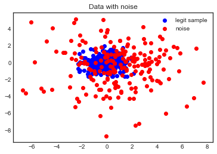

```python
plt.scatter(X_resampled[:,0], X_resampled[:,1], c='b', label='legit sample')
plt.scatter(noise[:,0], noise[:,1], c='r', label='noise')
plt.title('Data with noise')
plt.legend()
plt.show()
```

First, let's check how the Multivariate t Mixture deals with the noise data

```python
# Computing the scores
y_score = t_clf.score_samples(noise)
# setting the threshold
threshold = track2[6]['best'][0]
```

```python
# labeling the data acording to the threshold
y_pred = [1 if y_ < threshold else 0 for y_ in y_score]
y_pred = np.array(y_pred)
np.bincount(y_pred)
```

```
array([ 65, 135], dtype=int64)
```

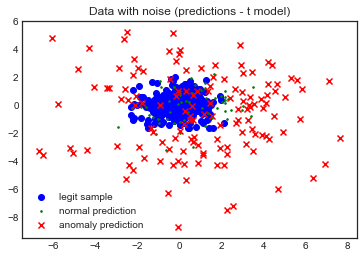

```python
plt.scatter(X_resampled[:,0], X_resampled[:,1], c='b', label='legit sample')

plt.scatter(noise[y_pred==0][:,0], noise[y_pred==0][:,1], c='g', marker='.', s=10, label='normal prediction')
plt.scatter(noise[y_pred==1][:,0], noise[y_pred==1][:,1], c='r', marker='x', label='anomaly prediction')
plt.title('Data with noise (predictions - t model)')
plt.legend()
plt.show()
```

As we can see on the plot, the model is dealing very well with the noise.  
Let's check the Gaussian model.

```python
y_score = gauss_clf.score_samples(noise)
# setting the threshold
threshold = track[3]['best'][0]
```

```python
y_pred = [1 if y_ < threshold else 0 for y_ in y_score]
y_pred = np.array(y_pred)
np.bincount(y_pred)
```

```
array([ 63, 137], dtype=int64)
```

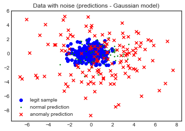

```python
plt.scatter(X_resampled[:,0], X_resampled[:,1], c='b', label='legit sample')

plt.scatter(noise[y_pred==0][:,0], noise[y_pred==0][:,1], c='g', marker='.', s=10, label='normal prediction')
plt.scatter(noise[y_pred==1][:,0], noise[y_pred==1][:,1], c='r', marker='x', label='anomaly prediction')
plt.title('Data with noise (predictions - Gaussian model)')
plt.legend()
plt.show()
```